# Reproducible Research: Peer Assessment 1

## Loading and preprocessing the data

First, check if a file called data.zip is already in the local directory, and if not, download the data from the URL given in the assignment, using the file name data.zip.

```r
if (!file.exists("data.zip")) {
  download.file("https://d396qusza40orc.cloudfront.net/repdata%2Fdata%2Factivity.zip", "data.zip")
}
```

Next, pull the data into R. The data has a header, so read with header=T.

```r
data <- read.csv(unz("data.zip", filename="activity.csv"), header=T)
```

Luckily everything is pretty tidy, so no pre-processing is needed.

## What is mean total number of steps taken per day?

To calculate total steps per day, group the data by date recorded and add up the total steps for each date. For now, we can just ignore NA values.

```r
dailySteps <- aggregate(steps ~ date, data, FUN = sum, na.rm=T)
```

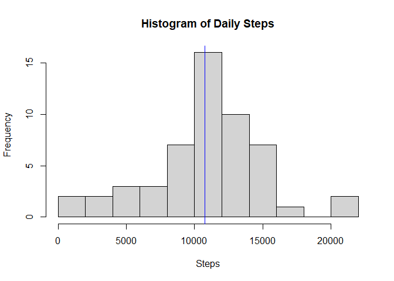

```r
hist(dailySteps$steps, breaks=10, xlab="Steps", ylab="Frequency", main="Histogram of Daily Steps")
abline(v=mean(dailySteps$steps), col="red")
abline(v=median(dailySteps$steps), col="blue")
```

## What is the average daily activity pattern?

To determine the average activity pattern throughout a typical day, group the data by time recorded (“interval”), and calculate average steps at each time. For now, we continue to ignore missing values.

```r
timeSteps <- aggregate(steps ~ interval, data, FUN = mean, na.rm=T)
```

To see what the data looks like, plot it as a time series against the intervals observed.

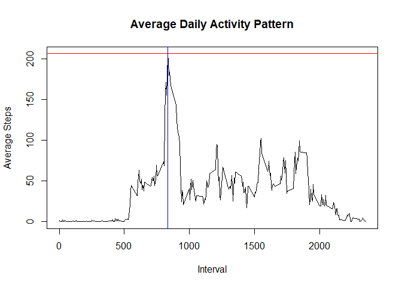

```r
plot(levels(factor(data$interval)), timeSteps$steps, type='l', xlab="Interval", ylab="Average Steps", main="Average Daily Activity Pattern")
maxTime <- levels(factor(data$interval))[which(timeSteps$steps == max(timeSteps$steps))]
abline(h=max(timeSteps$steps), col="red")
abline(v=maxTime, col="blue")
```

## Imputing missing values

To impute the missing values, the two obvious strategies are to insert typical values either for the day, or for the time interval. To get a sense of which may be more reliable, check the standard deviations of each measure.

```r
timeDevs <- aggregate(steps ~ interval, data, FUN = sd, na.rm=T)
dailyDevs <- aggregate(steps ~ date, data, FUN = sd, na.rm=T)
mean(timeDevs$steps)  #steps field now holds standard deviation
```

```
## [1] 82.97991
```

```r
mean(dailyDevs$steps)
```

```
## [1] 105.1223
```

Since the number of steps taken seem to vary less with the time than with the day, impute using the mean value for each time interval. First check which fields contain NA values:

```r
sapply(data, function(x) {any(is.na(x))}) #check which fields contain NA values
```

```
##    steps     date interval
##     TRUE    FALSE    FALSE
```

Since only steps has NA values, that is the only field that needs values imputed. Create a mask for which values are NA, record their intervals, then copy the data set and fill in the NA values with the corresponding means (from timeSteps, since that already has the means of steps by interval).

```r
whichNA <- is.na(data$steps)  #create mask for NA values
whichInterval <- data$interval[is.na(data$steps)] #record intervals of NA values
data2 <- data
data2$steps[whichNA] <- map_dbl(whichInterval, function(x) timeSteps$steps[which(timeSteps$interval==x)])
```

Next, recalculate total daily steps and re-plot as a histogram, but using data2.

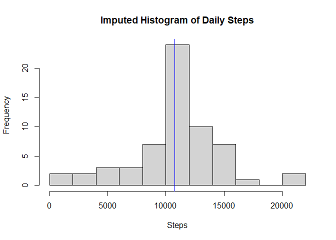

```r
dailySteps2 <- aggregate(steps ~ date, data2, FUN = sum, na.rm=T)
hist(dailySteps2$steps, breaks=10, xlab="Steps", ylab="Frequency", main="Imputed Histogram of Daily Steps")
abline(v=mean(dailySteps2$steps), col="red")
abline(v=median(dailySteps2$steps), col="blue")
```

## Are there differences in activity patterns between weekdays and weekends?

First, create a factor to reflect whether a given day is a weekday or weekend.

```r
wkdys <- c("Monday", "Tuesday", "Wednesday", "Thursday", "Friday")
data2$type <- factor(weekdays(as.Date(data2$date)) %in% wkdys, levels = c(TRUE, FALSE), labels = c("weekday", "weekend"))
```

Next, calculate and plot the typical activity patterns for weekdays and weekends

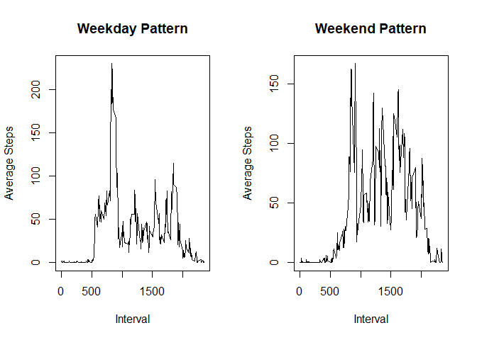

```r
daySteps <- aggregate(steps ~ interval, subset(data2, type=="weekday"), FUN=mean)
endSteps <- aggregate(steps ~ interval, subset(data2, type=="weekend"), FUN=mean)
par(mfrow=c(1,2))
plot(levels(factor(data2$interval)), daySteps$steps, type='l', xlab="Interval", ylab="Average Steps", main="Weekday Pattern")
plot(levels(factor(data2$interval)), endSteps$steps, type='l', xlab="Interval", ylab="Average Steps", main="Weekend Pattern")
```